# Checks on muvi duration in logfiles

While preparing concatenated time courses of all muvis for a Tensor ICA (TICA) analysis, I noticed that the total length was different across subjects. This should prevent the possibility of running not only TICA, but also ISC.

I decided to investigate further. I previously calculated the length of each muvi as `end_TR - start_TR`, so I first decided to instead check if the total lenght would be the same if, instead of using the *calculated* length, I would use the *expected* length of the muvi (which is also reported in the log file)

## Load libraries + csv of log_summary

NB: The `log_summary_FIXED.csv` contains the same info of the `log_summary.csv` prepared by Lorenzo, with just some additional columns and some fixes in the values - e.g. “sub_02” instead of “2” in the sub column - to fit my processing scripts

```r
library(tidyverse)
library(DT)
library(kableExtra)
library(rmarkdown)

df <- read_csv("log_summary_FIXED.csv")
```

## Checks on the *expected* duration

Check that all the concatenated time courses will be of identical length across subs. This might sound lame - since we use the ExpectedDuration which is a constant - however the ExpectedDuration is taken from the log file, and we want to check that the its value is the same in all subs.

```r
# start/end TR and expected duration for each muvi
df %>%
  group_by(muvi) %>%
  select(sub, run, muvi, start_TR, end_TR, ExpectedDuration) %>%
  arrange(muvi,run) %>% # group_split()
  paged_table
```

| sub | run | muvi | start_TR | end_TR | ExpectedDuration |
| --- | --- | --- | --- | --- | --- |
| sub_02 | 1 | M12letterD.avi | 32 | 42 | 10 |
| sub_03 | 1 | M12letterD.avi | 32 | 42 | 10 |
| sub_05 | 1 | M12letterD.avi | 32 | 42 | 10 |
| sub_06 | 1 | M12letterD.avi | 32 | 42 | 10 |
| sub_09 | 1 | M12letterD.avi | 31 | 41 | 10 |
| sub_10 | 1 | M12letterD.avi | 31 | 41 | 10 |
| sub_11 | 1 | M12letterD.avi | 31 | 41 | 10 |
| sub_12 | 1 | M12letterD.avi | 31 | 41 | 10 |
| sub_14 | 1 | M12letterD.avi | 32 | 42 | 10 |
| sub_02 | 2 | M12letterD.avi | 131 | 141 | 10 |

[output cut: 638 more lines]

```r
# In order for ISFC/TICA to be feasible, the concatenated time course
# of all movies must have the same length in all subs
df %>%
  group_by(sub) %>%
  select(sub,muvi,ExpectedDuration) %>%
  summarise(tot_TR = sum(ExpectedDuration), .groups="drop")
```

```
## # A tibble: 9 x 2
##   sub    tot_TR
##   <chr>   <dbl>
## 1 sub_02   1148
## 2 sub_03   1148
## 3 sub_05   1148
## 4 sub_06   1148
## 5 sub_09   1148
## 6 sub_10   1148
## 7 sub_11   1148
## 8 sub_12   1148
## 9 sub_14   1148
```

```r
# Checking that a given movie covers the same numba of time points
# in all subs. This is important since the the value could potentially
# differ in the log file of different subs, even though their sum - checked
# above - might still be the same.
# Briefly, the var_nTR in the table below should always be 0
df %>%
  group_by(muvi) %>%
  summarise(
    nTR_min = min(ExpectedDuration),
    nTR_max = max(ExpectedDuration),
    var_nTR = var(ExpectedDuration),
    .groups = "drop"
  ) %>%
  paged_table
```

| muvi | nTR_min | nTR_max | var_nTR |
| --- | --- | --- | --- |
| M12letterD.avi | 10 | 10 | 0 |
| M13lightD.avi | 12 | 12 | 0 |
| M14nailD.avi | 11 | 11 | 0 |
| M15juiceD.avi | 15 | 15 | 0 |
| M16pencilD.avi | 20 | 20 | 0 |
| M17pillowD.avi | 10 | 10 | 0 |
| M18removerD.avi | 15 | 15 | 0 |
| M19sandwichD.avi | 18 | 18 | 0 |
| M1ballonD.avi | 12 | 12 | 0 |
| M21toastD.avi | 15 | 15 | 0 |

[output cut: 26 more lines]

```r
# # Checking that the end_TR does not go above the recorded length of the fmri 4D
# # (data to be gathered using fsl in the terminal - CORRECT and long to display)
# df %>%
#   group_by(ses,task,run,sub) %>%
#   summarise(
#     max_end_TR = max(end_TR),
#     var_end_TR = var(max(end_TR)),
#     .groups = "drop"
#   ) %>%
#   group_by(sub) %>%
#   group_split()
```

## Checks on the *recorded* duration - i.e. that recorded in the log file. Problems here.

```r
# -------- PROBLEM HERE!! --------------------------------

# Calculate the total lenght of the time course for each sub if we consider
# end_TR - start_TR
df %>%
  group_by(sub) %>%
  select(sub,start_TR, end_TR) %>%
  mutate(CalculatedDuration = end_TR - start_TR) %>%
  summarise(total_tc_length = sum(CalculatedDuration))
```

```
## # A tibble: 9 x 2
##   sub    total_tc_length
##   <chr>            <dbl>
## 1 sub_02            1198
## 2 sub_03            1198
## 3 sub_05            1196
## 4 sub_06            1197
## 5 sub_09            1205
## 6 sub_10            1204
## 7 sub_11            1204
## 8 sub_12            1205
## 9 sub_14            1204
```

```r
# Mismatch between expected and recorded duration
# of the muvis.
# Note that there is some similarity across subjects (try group_by(sub) )
# and it happens only for 8 specific intact (M) muvis (try group_by(muvi) )
df %>%
  group_by(muvi) %>%
  select(muvi,start_TR, end_TR, ExpectedDuration) %>%
  mutate(
    CalculatedDuration = end_TR - start_TR,
    Expected_minus_Calculated = ExpectedDuration - CalculatedDuration
  ) %>%
  filter(Expected_minus_Calculated != 0) %>%
  # group_split()
  summarise(
    avgMismatch = mean(Expected_minus_Calculated)
  )
```

```
## # A tibble: 8 x 2
##   muvi             avgMismatch
##   <chr>                  <dbl>
## 1 M17pillowD.avi        -6.56
## 2 M19sandwichD.avi     -10.6
## 3 M21toastD.avi         -6.44
## 4 M22shirtD.avi        -10.2
## 5 M2boatD.avi           -9.56
## 6 M5cardD.avi           -9.33
## 7 M7flowersD.avi        -0.667
## 8 M8frameD.avi          -0.2
```

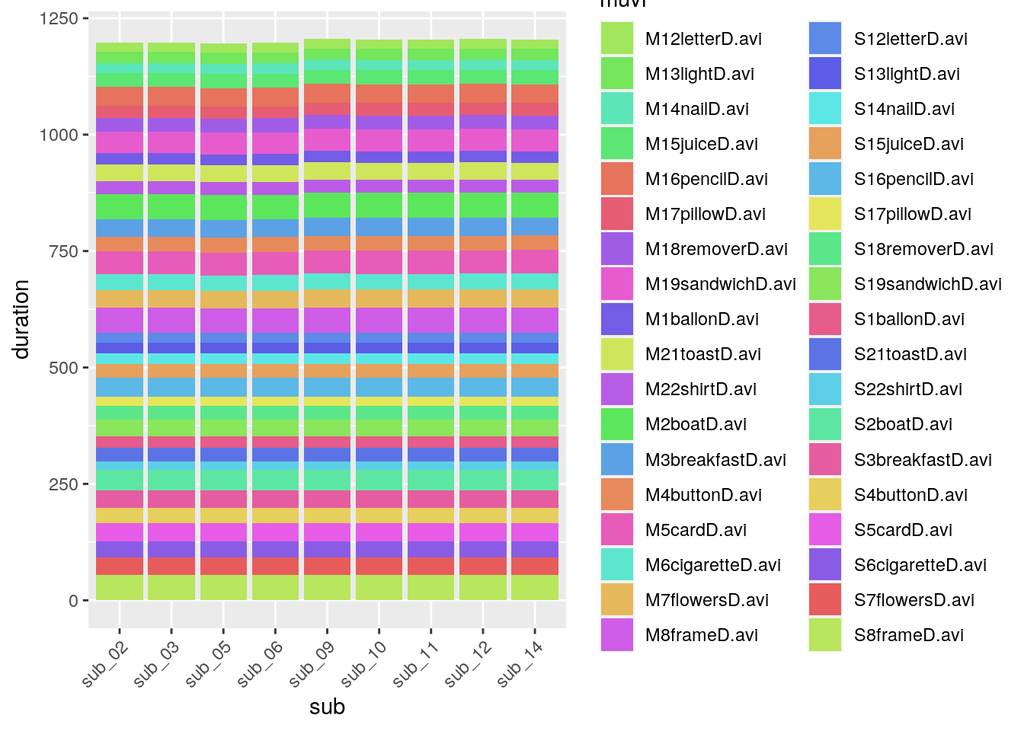

```r
# However in reality the misalignment does not look that big
n_muvis <- df$muvi %>% unique() %>% length
colori = rainbow(n_muvis, s=.6, v=.9)[sample(1:n_muvis,n_muvis)]

df %>%
  mutate(duration = end_TR - start_TR) %>%
  select(sub, muvi, duration) %>%
  arrange(sub,muvi) %>%
  ggplot(aes(fill = muvi, y = duration, x = sub)) +
    geom_bar(position = "stack", stat = "identity") +
    scale_fill_manual(values=colori) +
    theme(axis.text.x=element_text(angle=45, hjust=1))
```

## Fixing the problem using the expected rather than the recorded duration of the movie

```r
# To fix this, we can use the expected duration instead of the calculated.
# As we saw above, this will obviously allow to have concatenated time
# courses of the same lenght
df %>%
  group_by(sub) %>%
  select(sub,muvi,ExpectedDuration) %>%
  summarise(tot_TR = sum(ExpectedDuration), .groups="drop")
```

```
## # A tibble: 9 x 2
##   sub    tot_TR
##   <chr>   <dbl>
## 1 sub_02   1148
## 2 sub_03   1148
## 3 sub_05   1148
## 4 sub_06   1148
## 5 sub_09   1148
## 6 sub_10   1148
## 7 sub_11   1148
## 8 sub_12   1148
## 9 sub_14   1148
```

```r
# However I need to make sure that using start_TR + ExpectedDuration
# would not go over the recorded length of the time course.
# Let's check that.
df %>%
  select(muvi,start_TR, end_TR, ExpectedDuration, dim4) %>%
  mutate(
    ImposedDuration = start_TR + ExpectedDuration,
    overflow = ImposedDuration - dim4
  ) %>%
  filter(overflow > 0)
```

```
## # A tibble: 3 x 7
##   muvi           start_TR end_TR ExpectedDuration  dim4 ImposedDuration overflow
##   <chr>             <dbl>  <dbl>            <dbl> <dbl>           <dbl>    <dbl>
## 1 M8frameD.avi        194    220               27   220             221        1
## 2 M7flowersD.avi      202    220               19   220             221        1
## 3 M8frameD.avi        194    220               27   220             221        1
```

```r
# If I use start_TR + ExpectedDuration, I have three muvis that go
# over the length of the fmri 4D. This is probably because Lorenzo
# calculated the start_TR one volume after the recorded start volume
# of the muvi (it needs a shift -1).
# We can fix this by using start_TR - 1. This is better than
# ExpectedDuration - 1 since it also fixes the issue of the lacked shift.
df %>%
  select(muvi,start_TR, end_TR, ExpectedDuration, dim4) %>%
  mutate(
    ImposedDuration = (start_TR - 1) + ExpectedDuration,
    overflow = ImposedDuration - dim4
  ) %>%
  filter(overflow == 0)
```

```
## # A tibble: 3 x 7
##   muvi           start_TR end_TR ExpectedDuration  dim4 ImposedDuration overflow
##   <chr>             <dbl>  <dbl>            <dbl> <dbl>           <dbl>    <dbl>
## 1 M8frameD.avi        194    220               27   220             220        0
## 2 M7flowersD.avi      202    220               19   220             220        0
## 3 M8frameD.avi        194    220               27   220             220        0
```

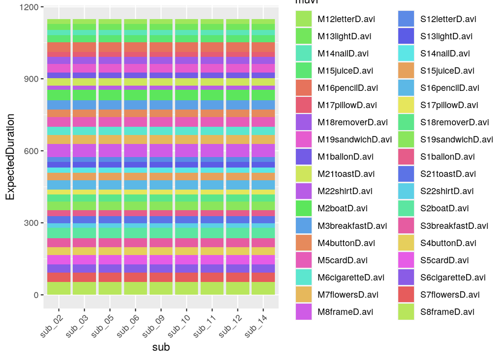

```r
# At this point everything is perfectly aligned
# NB: the colori is defined above, to have the same colors

df %>%
  select(sub, muvi, ExpectedDuration) %>%
  arrange(sub,muvi) %>%
  ggplot(aes(fill = muvi, y = ExpectedDuration, x = sub)) +
    geom_bar(position = "stack", stat = "identity") +
    scale_fill_manual(values=colori) +
    theme(axis.text.x=element_text(angle=45, hjust=1))
```